# Exploratory Analyses - Emma

Do countries run trials in the diseases that make up most of their burden? For each country, we compare its **trial mix** (share of classified trials in each GBD analysis category) with its **burden mix** (share of DALYs in each category). DALYs come from year *t* and trials from year *t + lag*.

Inputs are the outputs of the tidy script: `data/tidy/daly.rds` and `data/tidy/trial_cause.rds`. If `trial_cause.rds` was built with `allow_proposed: true`, these results are provisional.

```r
library(tidyverse)
library(countrycode)
library(plotly)

daly_df        = read_rds("data/tidy/daly.rds")
trial_cause_df = read_rds("data/tidy/trial_cause.rds")
countries      = read_rds("data/countries.rds")

lag_years   = 1            # trials start this many years after the burden year
min_trials  = 30           # countries with fewer classified trials are left off the maps
focus_cause = "Neoplasms"  # category shown in the second map
```

## Build the comparison table

```r
# One row per trial x country. Multinational trials count once in every country they list.
trial_country = countries |>
  mutate(
    iso3 = countrycode(country, "country.name", "iso3c", warn = FALSE),
    iso3 = if_else(country == "Serbia and Montenegro", NA_character_, iso3)
  ) |>
  filter(!is.na(iso3)) |>
  distinct(nct_id, iso3)

# Burden years that have trials starting `lag` years later
matched_years = function(lag) {
  burden_years = sort(unique(daly_df$year))
  burden_years[(burden_years + lag) %in% unique(trial_cause_df$start_year)]
}

# One row per country x analysis cause, pooling all matched years
build_comparison = function(lag) {
  burden_years = matched_years(lag)
  if (length(burden_years) == 0) {
    stop(
      "No burden year has trials starting ", lag, " year(s) later.\n",
      "  Burden years available: ", paste(sort(unique(daly_df$year)), collapse = ", "), "\n",
      "  Trial start years available: ", min(trial_cause_df$start_year), "-",
      max(trial_cause_df$start_year), "\n",
      "  Add earlier IHME years, or rerun the tidy script with a later trial_end_year."
    )
  }
  trial_years = burden_years + lag

  burden = daly_df |>
    filter(year %in% burden_years, !is.na(iso3)) |>
    group_by(iso3, analysis_cause_id, analysis_cause) |>
    summarize(location = first(location), daly = sum(daly), .groups = "drop") |>
    group_by(iso3) |>
    mutate(daly_share = daly / sum(daly)) |>
    ungroup()

  # Fractional counting: a trial in k categories adds 1/k to each one,
  # so a country's trial shares sum to 1, just like its DALY shares.
  trials = trial_cause_df |>
    filter(start_year %in% trial_years) |>
    transmute(nct_id, analysis_cause_id, weight = 1 / n_analysis_causes) |>
    inner_join(trial_country, by = "nct_id", relationship = "many-to-many") |>
    group_by(iso3, analysis_cause_id) |>
    summarize(trial_weight = sum(weight), n_trials = n_distinct(nct_id), .groups = "drop")

  burden |>
    left_join(trials, by = c("iso3", "analysis_cause_id")) |>
    mutate(across(c(trial_weight, n_trials), \(x) replace_na(x, 0))) |>
    group_by(iso3) |>
    mutate(
      n_classified_trials = round(sum(trial_weight)),
      trial_share = trial_weight / sum(trial_weight),
      # +0.5 pseudo-count so categories with zero trials still get a finite ratio
      trial_share_smoothed = (trial_weight + 0.5) / (sum(trial_weight) + 0.5 * n()),
      log2_ratio = log2(trial_share_smoothed / daly_share)
    ) |>
    ungroup() |>
    mutate(
      lag = lag,
      window = paste0("DALYs ", min(burden_years), "-", max(burden_years),
                      " vs trials starting ", min(trial_years), "-", max(trial_years))
    )
}

safe_spearman = function(x, y) {
  if (sd(x) == 0 || sd(y) == 0) return(NA_real_)
  cor(x, y, method = "spearman")
}

# One row per country: how far its trial mix is from its burden mix
summarize_alignment = function(comparison, min_trials) {
  comparison |>
    filter(n_classified_trials >= min_trials) |>
    group_by(iso3, location) |>
    summarize(
      n_classified_trials = first(n_classified_trials),
      # Share of trials that would have to move between categories to match burden (0-1)
      mismatch = 0.5 * sum(abs(trial_share - daly_share)),
      # Rank agreement across the 20 categories (-1 to 1)
      spearman = safe_spearman(trial_share, daly_share),
      top_burden = analysis_cause[which.max(daly_share)],
      top_research = analysis_cause[which.max(trial_share)],
      .groups = "drop"
    )
}
```

```r
comparison = build_comparison(lag_years)
alignment  = summarize_alignment(comparison, min_trials)

distinct(comparison, window)
```

```
## # A tibble: 1 × 1
##   window
##   <chr>
## 1 DALYs 2009-2022 vs trials starting 2010-2023
```

```r
alignment |>
  arrange(desc(mismatch)) |>
  mutate(mismatch = scales::percent(mismatch, 1), spearman = round(spearman, 2))
```

```
## # A tibble: 109 × 7
##    iso3  location  n_classified_trials mismatch spearman top_burden top_research
##    <chr> <chr>                   <dbl> <chr>       <dbl> <chr>      <chr>
##  1 KHM   Cambodia                   39 69%         -0.07 Cardiovas… Neglected t…
##  2 DZA   Algeria                    38 68%          0.4  Cardiovas… Diabetes an…
##  3 OMN   Oman                       42 65%          0.43 Injuries   Other non-c…
##  4 BFA   Burkina …                  79 63%          0.54 Neglected… Neglected t…
##  5 HND   Honduras                   46 62%          0.32 Injuries   Respiratory…
##  6 GMB   Gambia                     32 62%          0.45 Maternal … Neglected t…
##  7 CRI   Costa Ri…                  59 62%          0.13 Injuries   Neoplasms
##  8 ARM   Armenia                    41 62%          0.53 Cardiovas… Sense organ…
##  9 MLI   Mali                       69 61%          0.52 Maternal … Neglected t…
## 10 SYR   Syrian A…                  31 60%          0.52 Injuries   Other non-c…
## # ℹ 99 more rows
```

## Map 1: how well each country’s trial mix matches its burden

```r
geo_style = list(
  showframe = FALSE, showcoastlines = FALSE,
  showland = TRUE, landcolor = "#e5e5e5",
  showcountries = TRUE, countrycolor = "white",
  projection = list(type = "natural earth")
)

plot_ly(
  data = alignment,
  type = "choropleth",
  locations = ~iso3,
  locationmode = "ISO-3",
  z = ~100 * mismatch,
  colorscale = "Viridis",
  reversescale = TRUE,
  colorbar = list(title = "Mismatch (%)"),
  text = ~paste0(
    "<b>", location, "</b>",
    "<br>Classified trials: ", scales::comma(n_classified_trials),
    "<br>Mismatch: ", round(100 * mismatch), "% of trials",
    "<br>Spearman rho: ", round(spearman, 2),
    "<br>Largest burden: ", top_burden,
    "<br>Most-studied: ", top_research
  ),
  hoverinfo = "text"
) |>
  layout(
    title = paste0("Mismatch between trial mix and burden mix<br><sup>",
                   distinct(comparison, window)$window,
                   "; grey = fewer than ", min_trials, " classified trials</sup>"),
    geo = geo_style
  )
```

[interactive chart not shown]

Mismatch is the share of a country’s trials that would have to move between categories for the trial mix to match the burden mix. A value of 0% means a perfect match.

## Map 2: research relative to burden for one category

```r
if (!focus_cause %in% comparison$analysis_cause) {
  stop("focus_cause must be one of: ",
       paste(sort(unique(comparison$analysis_cause)), collapse = "; "))
}

focus_df = comparison |>
  filter(analysis_cause == focus_cause, n_classified_trials >= min_trials) |>
  mutate(ratio_capped = pmin(pmax(log2_ratio, -3), 3))

plot_ly(
  data = focus_df,
  type = "choropleth",
  locations = ~iso3,
  locationmode = "ISO-3",
  z = ~ratio_capped,
  zmin = -3, zmax = 3, zmid = 0,
  colorscale = "RdBu",
  colorbar = list(
    title = "Trial share /<br>DALY share",
    tickvals = -3:3,
    ticktext = c("1/8x", "1/4x", "1/2x", "1x", "2x", "4x", "8x")
  ),
  text = ~paste0(
    "<b>", location, "</b>",
    "<br>", focus_cause,
    "<br>Share of DALYs: ", scales::percent(daly_share, 0.1),
    "<br>Share of trials: ", scales::percent(trial_share, 0.1),
    " (", scales::comma(n_trials), " trials)",
    "<br>Ratio: ", round(2^log2_ratio, 2), "x"
  ),
  hoverinfo = "text"
) |>
  layout(
    title = paste0(focus_cause, ": share of trials vs share of burden<br><sup>",
                   distinct(comparison, window)$window, "</sup>"),
    geo = geo_style
  )
```

[interactive chart not shown]

Blue means the category gets more trials than its share of burden; red means fewer.

## The correlation itself

A map shows where things are, but not the correlation. Each panel below plots one category. Each point is a country. The dashed line is where trial share equals DALY share.

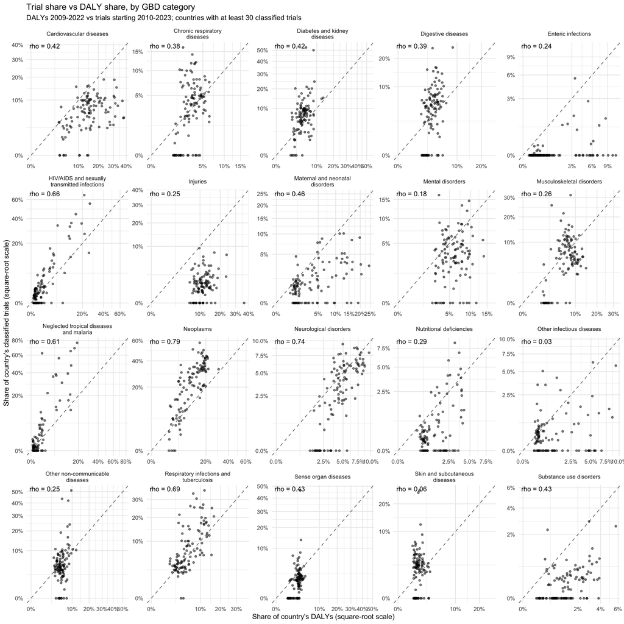

```r
plot_df = comparison |> filter(n_classified_trials >= min_trials)

cause_cor = plot_df |>
  group_by(analysis_cause) |>
  summarize(rho = safe_spearman(daly_share, trial_share), .groups = "drop") |>
  mutate(label = paste0("rho = ", round(rho, 2)))

# Give each panel the same range on both axes so the y = x line runs corner to corner
panel_limits = plot_df |>
  group_by(analysis_cause) |>
  summarize(lim = max(daly_share, trial_share), .groups = "drop") |>
  reframe(daly_share = c(0, lim), trial_share = c(0, lim), .by = analysis_cause)

plot_df |>
  ggplot(aes(x = daly_share, y = trial_share)) +
  geom_blank(data = panel_limits) +
  geom_abline(slope = 1, intercept = 0, linetype = "dashed", colour = "grey50") +
  geom_point(alpha = 0.5, size = 1) +
  geom_text(data = cause_cor, aes(label = label), x = -Inf, y = Inf,
            hjust = -0.1, vjust = 1.3, size = 3, inherit.aes = FALSE) +
  facet_wrap(~ analysis_cause, scales = "free", labeller = label_wrap_gen(28)) +
  scale_x_sqrt(labels = scales::percent) +
  scale_y_sqrt(labels = scales::percent) +
  labs(
    title = "Trial share vs DALY share, by GBD category",
    subtitle = paste0(distinct(comparison, window)$window,
                      "; countries with at least ", min_trials, " classified trials"),
    x = "Share of country's DALYs (square-root scale)",
    y = "Share of country's classified trials (square-root scale)"
  ) +
  theme_minimal(base_size = 9)
```

A positive rho means countries where a disease makes up more of the burden also put a larger share of their trials into it.

## Does the lag matter?

```r
tibble(lag = 0:3) |>
  mutate(res = map(lag, \(l) tryCatch(build_comparison(l), error = \(e) NULL))) |>
  filter(!map_lgl(res, is.null)) |>
  mutate(
    window = map_chr(res, \(d) first(d$window)),
    align  = map(res, \(d) summarize_alignment(d, min_trials)),
    n_countries     = map_int(align, nrow),
    median_mismatch = map_dbl(align, \(a) median(a$mismatch)),
    median_spearman = map_dbl(align, \(a) median(a$spearman, na.rm = TRUE))
  ) |>
  select(lag, window, n_countries, median_mismatch, median_spearman) |>
  knitr::kable(digits = 2)
```

| lag | window | n_countries | median_mismatch | median_spearman |
| --- | --- | --- | --- | --- |
| 0 | DALYs 2010-2023 vs trials starting 2010-2023 | 109 | 0.38 | 0.71 |
| 1 | DALYs 2009-2022 vs trials starting 2010-2023 | 109 | 0.38 | 0.71 |
| 2 | DALYs 2008-2021 vs trials starting 2010-2023 | 109 | 0.39 | 0.70 |
| 3 | DALYs 2008-2020 vs trials starting 2011-2023 | 108 | 0.40 | 0.67 |